# Final Project

Tiasia Saunders

2025-05-01

## Data Source

The original articles were retrieved from [Nexis Uni](https://www.lexisnexis.com/en-us/professional/academic/nexis-uni.page).

👉 [Link to articles.csv on Google Drive](https://drive.google.com/drive/folders/1lYh1Ya3htdd24Yre1LakjNi3La3eUhS1?dmr=1&ec=wgc-drive-hero-goto)

## Description of Data

The dataset includes articles published in the first month of Trump’s 2025 presidency (Jan2025-Feb2025) containing keywords related to DEI and the Trump administration. It includes variables like publication name, publication country, date, full article text, and a binary variable that I added to indicate whether the article is **domestic** or **international**.

## Content Analysis Plan

I plan to conduct a content analysis to compare how DEI-related issues were framed across domestic and international newspapers. I’ve created a **preliminary codebook** in my topic_modeling assignment to identify topic themes such as:

- **Trump Executive Orders**
- **Corporate DEI**
- **Federal Education Policy**
- **Airplane Helicopter Crash**
- **Trump Elon Muske**
- **Media Website Info** <- considered this not useful in my analysis

| **Topic Code** | **Label** | **Definition / Description** | **Key Terms / Keywords Detected** | **Included in Analysis?** |
| --- | --- | --- | --- | --- |
| `trump_executive_orders` | Trump Executive Orders | Articles focused on Trump’s federal executive actions or policies concerning DEI (Diversity, Equity, Inclusion). | “trump”, “order”, “execut”, “feder”, “presid”, “divers”, “donald”, “dei”, “govern”, “inclus” | ✅ Yes |
| `corporate_dei` | Corporate DEI | Coverage of corporate diversity programs, policies, or initiatives, especially those being criticized or removed. | “divers”, “dei”, “inclus”, “equiti”, “compani”, “polici”, “target”, “initi”, “back”, “program” | ✅ Yes |
| `federal_education_policy` | Federal Education Policy | DEI-related policies in the education sector, including federal funding or university programs. | “feder”, “fund”, “trump”, “educ”, “univers”, “state”, “program”, “order”, “student”, “grant” | ✅ Yes |
| `airplane_helicopter_crash` | Airplane/Helicopter Crash | Articles incidentally mentioning DEI during unrelated news events such as aircraft crashes. | “trump”, “crash”, “plane”, “washington”, “presid”, “divers”, “air”, “blame”, “helicopt”, “donald” | ⚠️ Partial (exclude or tag separately) |
| `trump_elon_musk` | Trump and Elon Musk | Broader commentary pieces linking Trump and Elon Musk in DEI or political discussions. | “trump”, “presid”, “donald”, “musk”, “govern”, “world”, “histori”, “month”, “day”, “american” | ✅ Yes |
| `media_website_info` | Media Website Info | Non-substantive content such as navigation menus or metadata—irrelevant to analysis. | “• news”, “art”, “sport”, “search”, “opinion”, “content”, “staff”, “submit”, “washington” | ❌ No (Exclude) |
| `other` | Other / Uncategorized | Articles that do not fit into the defined categories. | N/A | ⚠️ Considered if useful |

These categories are being developed based on the most frequent bigrams and common narrative themes. Preliminary coding involves using keyword matching and bigram frequency analysis to map patterns of coverage.

## Unit of Analysis

The unit of analysis is an individual news article. The content analysis will focus on examining several components within each article:

- The **publication_location column**
- The **dom_vs_intl column**
- The **tokenization/bigrams**
- The **sentiment analysis**
- The **topic modeling**

## DEI_Articles (my dataframe) Codebook:

| Variable Name | Description | Type | Example |
| --- | --- | --- | --- |
| `V1` | Article index number (row ID) | Numeric | 1, 958, 1916 |
| `title` | Title of the article | Character | “Trump attacks DEI programs” |
| `published_date` | Date when the article was published | Date | 2025-01-28 |
| `publication_location` | Geographic location of the news outlet (e.g., country, city) | Character | “New York, USA” |
| `publication_4` | News outlet name (alternate or duplicate of another publication variable) | Character | “New York Times” |
| `publication_type_5` | Type of publication (e.g., newspaper, magazine, wire service) | Character | “Newspaper”, “Wire” |
| `length` | Length of article in characters | Numeric | 690.5 |
| `section` | Section of the newspaper or outlet (e.g., Politics, Opinion) | Character | “Politics”, “Business” |
| `word_count` | Number of words in the article | Numeric | 829 |
| `countries` | Countries mentioned in the article | Character | “United States, China” |
| `byline` | Author(s) of the article | Character | “By Jane Doe” |
| `agg_copyright` | Aggregated copyright info (not used; all values = NA) | Logical | NA |
| `cite` | Citation or source identifier | Character | “NYT-123456” |
| `company` | Parent media company | Character | “Gannett”, “News Corp” |
| `headline` | Headline as printed in the publication | Character | “Trump’s DEI Agenda” |
| `hlead` | Headline lead/summary sentence | Character | “Former president escalates…” |
| `publication_16` | Possibly a duplicate of `publication_4` | Character | “The Guardian” |
| `publication_type_17` | Possibly a duplicate of `publication_type_5` | Character | “Online”, “Print” |
| `pub_copyright` | Copyright info (not used; all values = NA) | Logical | NA |
| `show` | Possibly denotes whether the article is from a show or broadcast (unused) | Logical | NA |
| `term` | Possibly indicates search term used (all values = NA) | Logical | NA |
| `ticker` | Possibly stock ticker (unused) | Logical | NA |
| `index` | Article index or tag | Character | “trump_dei_001” |
| `filename` | Name of the file where article is stored | Character | “nyt_2024_01_23_trump.txt” |
| `filepath` | Full path to the article file | Character | “/Users/tiasia/articles/…” |

### Analysis Codebook

| Code | Definition | Example |
| --- | --- | --- |
| Tone_Positive | Article uses language reflecting hope, resolution, or positive outcomes | “Protesters call for reform, urge peaceful change” |
| Tone_Negative | Article uses alarmist or fear-inducing language | “Mob storms the Capitol in unprecedented violence” |
| Dom_vs_intl | Classifies the article as Domestic or International | Domestic (e.g. NYT), International (e.g. BBC) |
| Political_Affiliation | Implies alignment with a political ideology or party | “Left-wing activists confront right-wing group” |

> *Note: Codebook is subject to refinement following further testing.*

# Analysis Work

## Load Libraries

```r
library(tidyverse)
library(tidytext)
library(lubridate)
library(stringr)
library(ggplot2)
library(dplyr)
library(googledrive)
library(quanteda)
library(tm)
library(topicmodels)
library(lda)
library(ldatuning)
library(DT)
library(knitr)
library(kableExtra)
library(reshape2)
library(wordcloud)
library(pals)
library(SnowballC)
library(flextable)
library(rio)
```

## Loading Trump DEI data

```r
googledrive::drive_deauth()
temp_file <- tempfile()
drive_download(as_id("1fexSMTg_wJOpyh_XCuc_3_2CP_FGS_tB"), path = temp_file)
```

```
## File downloaded:
```

```
## • 'trump_dei_final_index.csv' <id: 1fexSMTg_wJOpyh_XCuc_3_2CP_FGS_tB>
```

```
## Saved locally as:
```

```
## • '/var/folders/6w/sgrmrps15mdf4l6v1k79k5bc0000gn/T//RtmproEgCz/fileb7b73a0c5fdf'
```

```r
#the file id is in the URL for your trump_dei_final_index.csv. which you get from clicking "Share on the Google Drive version and copying the link: https://drive.google.com/file/d/1fexSMTg_wJOpyh_XCuc_3_2CP_FGS_tB/view?usp=sharing
#https://drive.google.com/file/d/1fexSMTg_wJOpyh_XCuc_3_2CP_FGS_tB/view?usp=sharing
#your file id: "1fexSMTg_wJOpyh_XCuc_3_2CP_FGS_tB"'

# Then import the downloaded file from your hard drive
dei_articles <- rio::import(temp_file, format = "csv") # If you know the file format, specify it explicitly..."csv" or "xlsx", "txt", etc.
```

## Publication Count

```r
#filtered for 10mor more articles, 30 publications and 1479  articles
dei_articles |>
  count(publication_4) |>
  filter( n> 10) %>%
  arrange(desc(n))
```

```
##                       publication_4   n
## 1   CE Noticias Financieras English 337
## 2                   University Wire 301
## 3                       TheHill.com 105
## 4                        MailOnline  94
## 5  The Independent (United Kingdom)  92
## 6            The Guardian  (London)  67
## 7                  USA Today Online  61
## 8          The Times of India (TOI)  55
## 9                   telegraph.co.uk  44
## 10                The Baltimore Sun  29
## 11     The Daily Telegraph (London)  21
## 12                   thetimes.co.uk  21
## 13    Star Tribune (Minneapolis MN)  20
## 14                  Hindustan Times  19
```

[output cut: 16 more lines]

```r
### filter out publication to those who have 10 or more (already did ), mutate new column categorizing the 30 publicaations with centrist, left or right based on the media bias charts resources, add case_when
```

## Number of columns and rows

```r
print(paste0("This dataset has ", nrow(dei_articles), " rows and ", ncol(dei_articles), " columns."))
```

```
## [1] "This dataset has 1916 rows and 25 columns."
```

## Descriptive Statistics

```r
summary(dei_articles)
```

```
##        V1            title           published_date       publication_location
##  Min.   :   1.0   Length:1916        Min.   :2025-01-20   Length:1916
##  1st Qu.: 479.8   Class :character   1st Qu.:2025-01-28   Class :character
##  Median : 958.5   Mode  :character   Median :2025-02-03   Mode  :character
##  Mean   : 958.5                      Mean   :2025-02-03
##  3rd Qu.:1437.2                      3rd Qu.:2025-02-11
##  Max.   :1916.0                      Max.   :2025-02-20
##  publication_4      publication_type_5     length          section
##  Length:1916        Length:1916        Min.   :   40.0   Length:1916
##  Class :character   Class :character   1st Qu.:  472.0   Class :character
##  Mode  :character   Mode  :character   Median :  690.5   Mode  :character
##                                        Mean   :  829.7
##                                        3rd Qu.:  980.0
##                                        Max.   :11304.0
##    word_count       countries            byline          agg_copyright
##  Min.   :   40.0   Length:1916        Length:1916        Mode:logical
##  1st Qu.:  472.0   Class :character   Class :character   NA's:1916
##  Median :  690.5   Mode  :character   Mode  :character
##  Mean   :  829.7
##  3rd Qu.:  980.0
##  Max.   :11304.0
##      cite             company            headline            hlead
##  Length:1916        Length:1916        Length:1916        Length:1916
##  Class :character   Class :character   Class :character   Class :character
##  Mode  :character   Mode  :character   Mode  :character   Mode  :character
##
##
##
##  publication_16     publication_type_17 pub_copyright    show
##  Length:1916        Length:1916         Mode:logical   Mode:logical
##  Class :character   Class :character    NA's:1916      NA's:1916
##  Mode  :character   Mode  :character
##
##
##
##    term          ticker           index             filename
##  Mode:logical   Mode:logical   Length:1916        Length:1916
##  NA's:1916      NA's:1916      Class :character   Class :character
##                                Mode  :character   Mode  :character
##
##
##
##    filepath
##  Length:1916
##  Class :character
##  Mode  :character
##
##
##
```

## Frequency count for each category and their location

```r
table(dei_articles$dom_vs_intl)
```

```
## < table of extent 0 >
```

```r
table(dei_articles$publication_location)
```

```
##
##           Arizona        California       Connecticut Dist. of Columbia
##                 3                27                 9               107
##           Florida           Georgia             Idaho          Illinois
##                10                 9                 1                14
##     International              Iowa            Kansas         Louisiana
##              1133                 5                 1                 1
##             Maine          Maryland         Minnesota          Missouri
##                18                36                21                 4
##     New Hampshire        New Mexico          New York      North Dakota
##                 1                 5                15                 7
##              Ohio            Oregon      Pennsylvania      U.S. Federal
##                 8                 1                66               388
##              Utah          Virginia        Washington     West Virginia
##                 8                 4                 6                 2
##         Wisconsin
##                 6
```

### Adding categorizing columns such as dom_vs_intl to indicate whether the article is from an international or domestic outlet

```r
dei_articles <- dei_articles |>
 #mutating a new column to indicate whether the pub location is international or domestic

mutate(dom_vs_intl = case_when (
  publication_location == "International" ~ "INTL",
  publication_location != "International" ~ "US",
  TRUE ~ NA
))
```

## Top 5 Domestic Articles

```r
top_five_domestic <- dei_articles |>
  filter(dom_vs_intl == "US") |>
  count(publication_4, sort = TRUE) |>
  slice_max(n, n = 5)

print(top_five_domestic)
```

```
##                   publication_4   n
## 1               University Wire 301
## 2                   TheHill.com 105
## 3              USA Today Online  61
## 4             The Baltimore Sun  29
## 5 Star Tribune (Minneapolis MN)  20
```

## Top 5 International Articles

```r
top_five_intl <- dei_articles |>
  filter(dom_vs_intl == "INTL") |>
  count(publication_4, sort = TRUE) |>
  slice_max(n, n = 5)
print(top_five_intl)
```

```
##                      publication_4   n
## 1  CE Noticias Financieras English 337
## 2                       MailOnline  94
## 3 The Independent (United Kingdom)  92
## 4           The Guardian  (London)  67
## 5         The Times of India (TOI)  55
```

### GGplot of the articles over time: From the 01/20-02-20– one month of Trump’s 2025 presidency

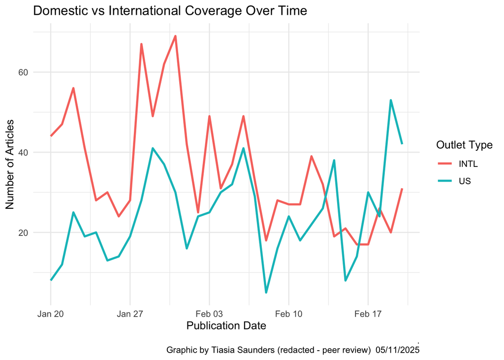

```r
df_time <- dei_articles |>
  count(published_date, dom_vs_intl)

ggplot(df_time, aes(x = published_date, y = n, color = dom_vs_intl)) +
  geom_line(size = 1) +
  labs(
    title = "Domestic vs International Coverage Over Time",
    x = "Publication Date",
    y = "Number of Articles",
    color = "Outlet Type",
    caption = ".\nGraphic by Tiasia Saunders (redacted - peer review)  05/11/2025"
  ) +
  theme_minimal()
```

### Graphic of Domestic versus International Outlet Distribution

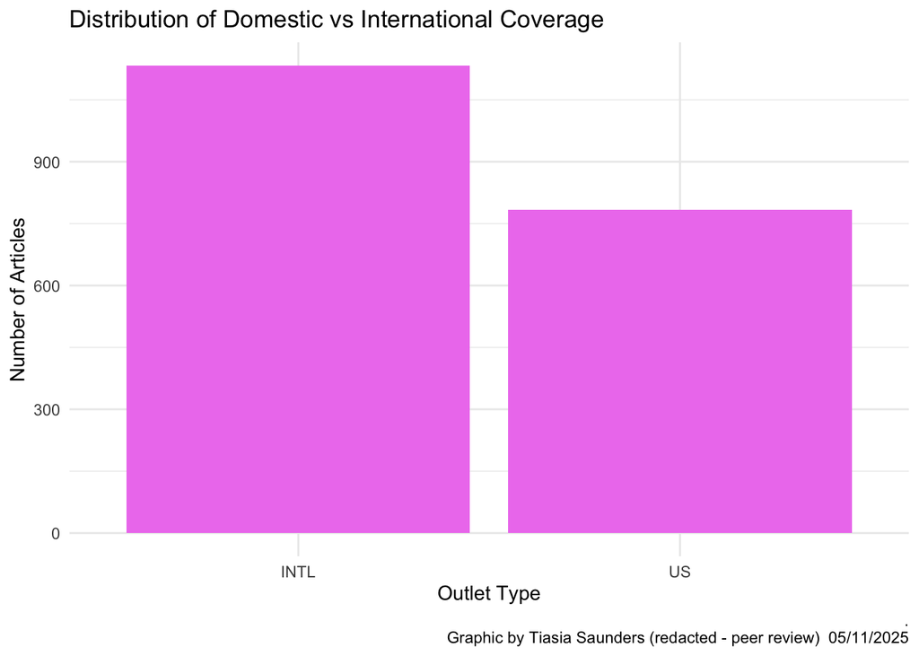

```r
ggplot(dei_articles, aes(x = dom_vs_intl)) +
  geom_bar(fill = "violet") +
  labs(
    title = "Distribution of Domestic vs International Coverage",
    x = "Outlet Type",
    y = "Number of Articles",
      caption = ".\nGraphic by Tiasia Saunders (redacted - peer review)  05/11/2025"
  ) +

  theme_minimal()
```

## Tokenizing Data

```r
stories <- str_replace_all(dei_articles$hlead, "- ", "")
stories_df <- tibble(stories)

# unnest includes lower, punct removal

stories_tokenized <- stories_df %>%
  unnest_tokens(word,stories)

stories_tokenized
```

```
## # A tibble: 201,142 × 1
##    word
##    <chr>
##  1 what
##  2 is
##  3 dei
##  4 why
##  5 did
##  6 trump
##  7 fire
##  8 all
##  9 dei
## 10 workers
## # ℹ 201,132 more rows
```

#### Remove stopwords and count the words

```r
stories_tokenized <- stories_tokenized |>
  anti_join(stop_words, by = c("word" = "word"))
```

### Word Count

```r
story_word_ct <- stories_tokenized %>%
  count(word, sort=TRUE)
```

### Create Bigrams

```r
bigrams <- stories_df %>%
  unnest_tokens(bigram, stories, token="ngrams", n=2)

bigrams
```

```
## # A tibble: 199,226 × 1
##    bigram
##    <chr>
##  1 what is
##  2 is dei
##  3 dei why
##  4 why did
##  5 did trump
##  6 trump fire
##  7 fire all
##  8 all dei
##  9 dei workers
## 10 workers on
## # ℹ 199,216 more rows
```

```r
#Filter out stop words.

bigrams1 <- bigrams %>%
  separate(bigram, c("word1", "word2"), sep = " ")

filtered_bigrams <- bigrams1 %>%
  filter(!word1 %in% stop_words$word) %>%
  filter(!word2 %in% stop_words$word) |>
    filter(!is.na(word1)) |>
     filter(!is.na(word2))

counted_bigrams <- filtered_bigrams %>%
  count(word1, word2, sort = TRUE)
```

## Top twenty bigrams

```r
top_bigrams <- counted_bigrams |>
  arrange(desc(n), word1, word2) |>
  head(20)
```

### Graphic of the Top 20 Most Frequent Biagrams

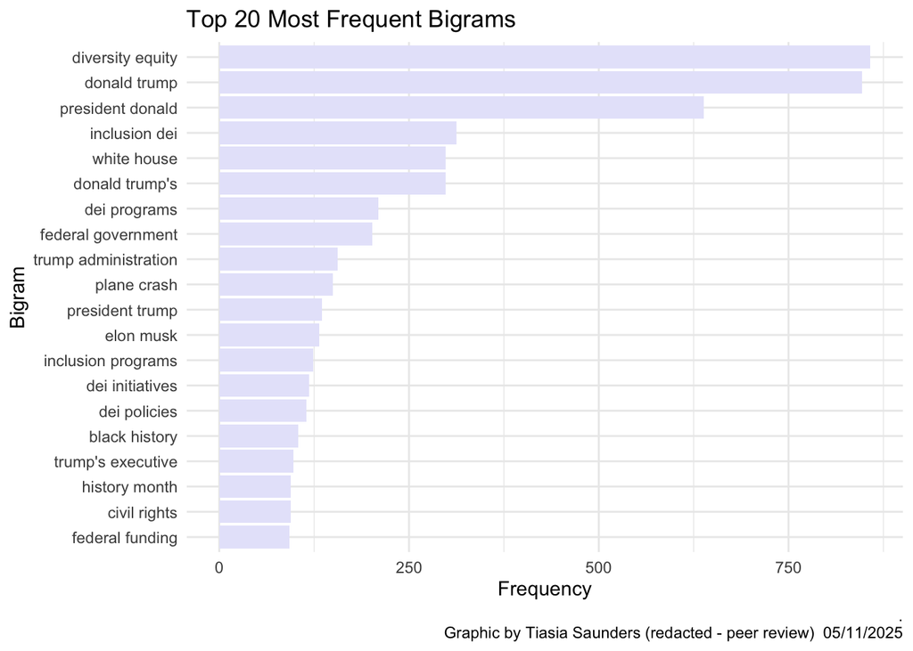

```r
# Combine the bigram into one string for labeling
top_bigrams <- counted_bigrams |>
  arrange(desc(n), word1, word2) |>
  head(20) |>
  mutate(bigram = paste(word1, word2))

# Plot
ggplot(top_bigrams, aes(x = reorder(bigram, n), y = n)) +
  geom_col(fill = "lavender") +
  coord_flip() +
  labs(
    title = "Top 20 Most Frequent Bigrams",
    x = "Bigram",
    y = "Frequency",
      caption = ".\nGraphic by Tiasia Saunders (redacted - peer review)  05/11/2025"
  ) +
  theme_minimal()
```

## Creating Domestic articles tokenization

```r
dom_dei_articles <- dei_articles  |>
  filter(dom_vs_intl == "US")


stories <- str_replace_all(dom_dei_articles$hlead, "- ", "")
dom_stories_df <- tibble(stories)

# unnest includes lower, punct removal

dom_stories_tokenized <- dom_stories_df %>%
  unnest_tokens(word,stories)

dom_stories_tokenized
```

```
## # A tibble: 85,383 × 1
##    word
##    <chr>
##  1 trump
##  2 moves
##  3 to
##  4 dismantle
##  5 federal
##  6 dei
##  7 efforts
##  8 washington
##  9 president
## 10 donald
## # ℹ 85,373 more rows
```

```r
dom_stories_tokenized <-dom_stories_tokenized |>
  anti_join(stop_words, by = c("word" = "word"))

story_word_ct <- dom_stories_tokenized %>%
  count(word, sort=TRUE)
```

### Creating International articles tokenization

```r
intl_dei_articles <- dei_articles  |>
  filter(dom_vs_intl == "INTL")


stories <- str_replace_all(intl_dei_articles$hlead, "- ", "")
intl_stories_df <- tibble(stories)

# unnest includes lower, punct removal

intl_stories_tokenized <- intl_stories_df %>%
  unnest_tokens(word,stories)

intl_stories_tokenized
```

```
## # A tibble: 115,759 × 1
##    word
##    <chr>
##  1 what
##  2 is
##  3 dei
##  4 why
##  5 did
##  6 trump
##  7 fire
##  8 all
##  9 dei
## 10 workers
## # ℹ 115,749 more rows
```

```r
intl_stories_tokenized <- intl_stories_tokenized |>
  anti_join(stop_words, by = c("word" = "word"))

story_word_ct <- intl_stories_tokenized %>%
  count(word, sort=TRUE)
```

## Sentiment Analysis

```r
nrc_sentiments <- get_sentiments("nrc")
afinn_sentiments <- get_sentiments("afinn")
```

#### Joining Domestic and Sentiment

```r
sentiments_dom_all <- dom_stories_tokenized |>
  inner_join(nrc_sentiments)
dom_overall_sentiment_count <- sentiments_dom_all |>
  count(sentiment) |>
  arrange(desc(n))
```

#### Joining International and Sentiment

```r
sentiments_intl_all <- intl_stories_tokenized |>
  inner_join(nrc_sentiments)
intl_overall_sentiment_count <- sentiments_intl_all |>
  count(sentiment) |>
  arrange(desc(n))
```

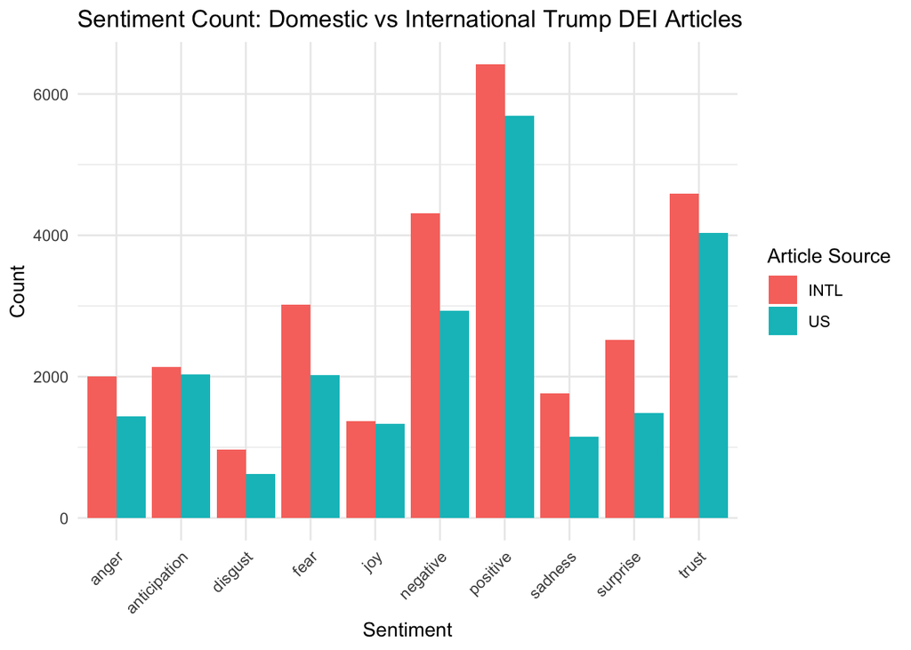

```r
# Add source labels
dom_overall_sentiment_count <- dom_overall_sentiment_count |>
  mutate(source = "US")

intl_overall_sentiment_count <- intl_overall_sentiment_count |>
  mutate(source = "INTL")

# Combine both dataframes
combined_sentiment <- bind_rows(dom_overall_sentiment_count, intl_overall_sentiment_count)

# Plot
ggplot(combined_sentiment, aes(x = sentiment, y = n, fill = source)) +
  geom_bar(stat = "identity", position = "dodge") +
  labs(
    title = "Sentiment Count: Domestic vs International Trump DEI Articles",
    x = "Sentiment",
    y = "Count",
    fill = "Article Source"
  ) +
  theme_minimal() +
  theme(axis.text.x = element_text(angle = 45, hjust = 1))
```

```r
sentiments_all <-stories_tokenized |>
  inner_join(nrc_sentiments)
```

### Overall Sentiment Count

```r
overall_sentiment_count <- sentiments_all |>
  count(sentiment) |>
  arrange(desc(n))
```

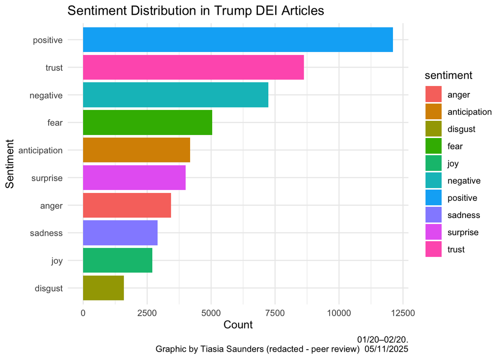

```r
ggplot(overall_sentiment_count, aes(x = reorder(sentiment, n), y = n, fill = sentiment)) +
  geom_bar(stat = "identity") +
  coord_flip() +
  labs(
    title = "Sentiment Distribution in Trump DEI Articles",
    x = "Sentiment",
    y = "Count",
    caption = "01/20–02/20.\nGraphic by Tiasia Saunders (redacted - peer review)  05/11/2025"
  ) +
  theme_minimal()
```

### Leading postive sentiment

```r
overall_postive_count <- sentiments_all |>
   filter(sentiment == "positive") |>
  count(sentiment,word) |>
  arrange(desc(n))

print(overall_postive_count)
```

```
## # A tibble: 959 × 3
##    sentiment word             n
##    <chr>     <chr>        <int>
##  1 positive  president     1326
##  2 positive  equity         949
##  3 positive  united         228
##  4 positive  university     205
##  5 positive  content        201
##  6 positive  including      200
##  7 positive  public         186
##  8 positive  civil          129
##  9 positive  aid            128
## 10 positive  inauguration   112
## # ℹ 949 more rows
```

### Leading Negative Sentiment

```r
overall_negative_count <- sentiments_all |>
   filter(sentiment == "negative") |>
  count(sentiment,word) |>
  arrange(desc(n))

print(overall_negative_count)
```

```
## # A tibble: 1,033 × 3
##    sentiment word               n
##    <chr>     <chr>          <int>
##  1 negative  government       620
##  2 negative  crash            289
##  3 negative  war              149
##  4 negative  discrimination   137
##  5 negative  foreign          120
##  6 negative  leave            111
##  7 negative  skip             111
##  8 negative  collision        102
##  9 negative  ban               88
## 10 negative  force             79
## # ℹ 1,023 more rows
```

### Getting the top twenty words for each sentiment

```r
# Get the top 20 words per sentiment
top_words_per_sentiment <- sentiments_all |>
  group_by(sentiment, word) |>
  summarise(count = n(), .groups = "drop") |>
  arrange(sentiment, desc(count)) |>
  group_by(sentiment) |>
  slice_max(order_by = count, n = 20)
```

## Graphic of Sentiment Breakdown for Domestic Articles

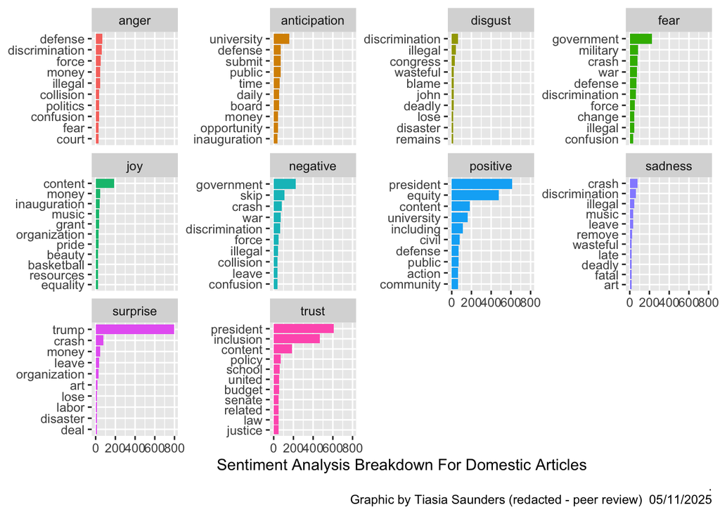

```r
sentiments_dom_all %>%
  count(sentiment, word) %>%
  group_by(sentiment) %>%
  slice_max(n, n = 10) %>%
  ungroup() %>%
  mutate(word = reorder_within(word, n, sentiment)) %>%
  ggplot(aes(n, word, fill = sentiment)) +
  geom_col(show.legend = FALSE) +
  facet_wrap(~sentiment, scales = "free_y") +
  scale_y_reordered() +
  labs(
    x = "Sentiment Analysis Breakdown For Domestic Articles",
    y = NULL,
    caption = ".\nGraphic by Tiasia Saunders (redacted - peer review)  05/11/2025"
  )
```

## Graphic of Sentiment Breakdown for International Articles

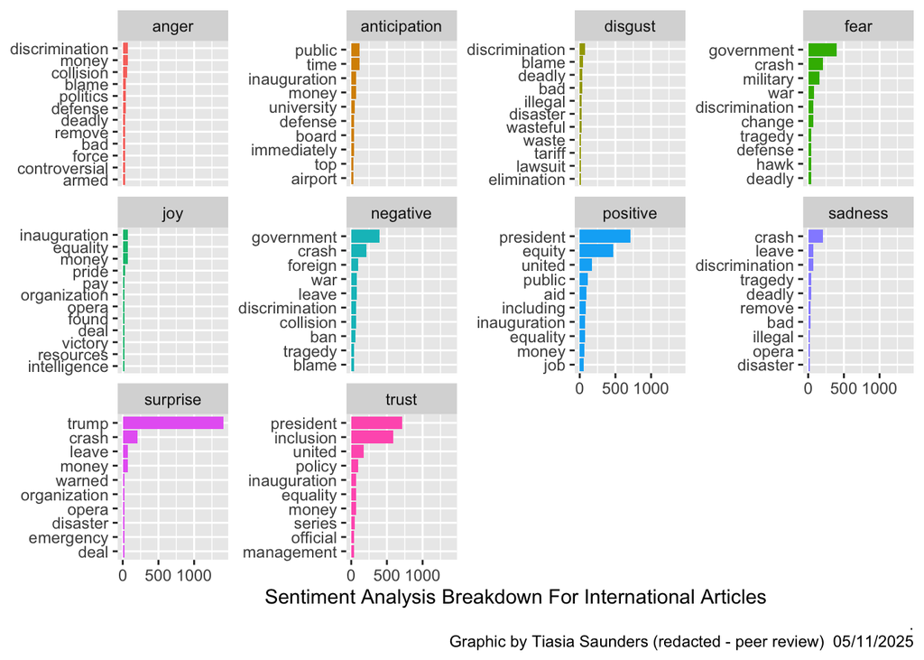

```r
sentiments_intl_all %>%
  count(sentiment, word) %>%
  group_by(sentiment) %>%
  slice_max(n, n = 10) %>%
  ungroup() %>%
  mutate(word = reorder_within(word, n, sentiment)) %>%
  ggplot(aes(n, word, fill = sentiment)) +
  geom_col(show.legend = FALSE) +
  facet_wrap(~sentiment, scales = "free_y") +
  scale_y_reordered() +
  labs(
    x = "Sentiment Analysis Breakdown For International Articles",
    y = NULL,
    caption = ".\nGraphic by Tiasia Saunders (redacted - peer review)  05/11/2025"
  )
```

## Topic Modeling

```r
textdata <- dei_articles |>

  select(filename, hlead, published_date, publication_location, dom_vs_intl) |>
  as.data.frame() |>
  rename(doc_id = filename, text= hlead)

# load stopwords
english_stopwords <- readLines("https://slcladal.github.io/resources/stopwords_en.txt", encoding = "UTF-8")
# create corpus object
corpus <- Corpus(DataframeSource(textdata))
# Preprocessing chain
processedCorpus <- tm_map(corpus, content_transformer(tolower))
processedCorpus <- tm_map(processedCorpus, removeWords, english_stopwords)
processedCorpus <- tm_map(processedCorpus, removePunctuation, preserve_intra_word_dashes = TRUE)
processedCorpus <- tm_map(processedCorpus, removeNumbers)
processedCorpus <- tm_map(processedCorpus, stemDocument, language = "en")
processedCorpus <- tm_map(processedCorpus, stripWhitespace)
```

```r
#DTM: rows correspond to the documents in the corpus. Columns correspond to the terms in the documents. Cells correspond to the weights of the terms. (Girder)
# compute document term matrix with terms >= minimumFrequency
minimumFrequency <- 5
DTM <- DocumentTermMatrix(processedCorpus, control = list(bounds = list(global = c(minimumFrequency, Inf))))
# have a look at the number of documents and terms in the matrix
dim(DTM)
```

```
## [1] 1916 2553
```

```r
# due to vocabulary pruning, we have empty rows in our DTM
# LDA does not like this. So we remove those docs from the
# DTM and the metadata
sel_idx <- slam::row_sums(DTM) > 0
DTM <- DTM[sel_idx, ]
textdata <- textdata[sel_idx, ]
#5 term minimum[1] 1387 3019
#5 term minimum[1] 308597 10339
```

## Topic proportions over time

```r
# dont need this since i am not using dates
textdata$day <- weekdays(as.Date(textdata$published_date, format="%Y-%m-%d"))
```

## Articles per international vs domestic newspapers

```r
## Articles per international vs domestic newspapers

articles_per_dom_intl_category <- textdata |>
  distinct(doc_id, .keep_all=TRUE) |>
  count(dom_vs_intl) |>
  mutate(pct_total = (n / sum(n))) |>
  mutate(pct_total = formattable::percent(pct_total)) |>
  arrange(desc(dom_vs_intl))

articles_per_dom_intl_category %>%
  kbl(caption = "Trump DEI Articles Per Outlet Type", font_size = 30) %>%
  kable_classic(full_width = F, html_font = "Cambria") %>%
  column_spec(1, bold = T, border_right = T) %>%
  column_spec(2, width = "5em") %>%
  column_spec(3, width = "5em", background = "yellow")
```

Trump DEI Articles Per Outlet Type

| dom_vs_intl | n | pct_total |
| --- | --- | --- |
| US | 783 | 40.87% |
| INTL | 1133 | 59.13% |

```r
sum(articles_per_dom_intl_category$n)
```

```
## [1] 1916
```

```r
# number of topics
# K <- 20
K <- 6
# set random number generator seed
set.seed(9161)
#Latent Dirichlet Allocation, LDA
topicModel2 <- LDA(DTM, K, method="Gibbs", control=list(iter = 500, verbose = 25, alpha = 0.2))
```

```
## K = 6; V = 2553; M = 1916
## Sampling 500 iterations!
## Iteration 25 ...
## Iteration 50 ...
## Iteration 75 ...
## Iteration 100 ...
## Iteration 125 ...
## Iteration 150 ...
## Iteration 175 ...
## Iteration 200 ...
## Iteration 225 ...
## Iteration 250 ...
## Iteration 275 ...
## Iteration 300 ...
## Iteration 325 ...
## Iteration 350 ...
## Iteration 375 ...
## Iteration 400 ...
## Iteration 425 ...
## Iteration 450 ...
## Iteration 475 ...
## Iteration 500 ...
## Gibbs sampling completed!
```

```r
tmResult <- posterior(topicModel2)
theta <- tmResult$topics
beta <- tmResult$terms
topicNames <- apply(terms(topicModel2, 10), 2, paste, collapse = " ")  # reset topicnames
```

### Mean topic proportions per domestic and international category

```r
# Step 1: Check dimensions
# Ensure doc_id and rownames are character
rownames(theta) <- as.character(rownames(theta))
textdata$doc_id <- as.character(textdata$doc_id)

# Get common document IDs
common_ids <- intersect(rownames(theta), textdata$doc_id)

# Filter both datasets to only include common documents
theta_aligned <- theta[rownames(theta) %in% common_ids, ]
textdata_filtered <- textdata[textdata$doc_id %in% common_ids, ]

# Reorder textdata_filtered to match theta_aligned
textdata_filtered <- textdata_filtered[match(rownames(theta_aligned), textdata_filtered$doc_id), ]

# Check that everything lines up
if (!all(rownames(theta_aligned) == textdata_filtered$doc_id)) {
  stop("The document IDs still do not match. Please check the data alignment.")
}

# Print dimensions
n_theta <- nrow(theta_aligned)
n_textdata_filtered <- nrow(textdata_filtered)
cat("Number of aligned theta rows: ", n_theta, "\n")
```

```
## Number of aligned theta rows:  1916
```

```r
cat("Number of aligned textdata rows: ", n_textdata_filtered, "\n")
```

```
## Number of aligned textdata rows:  1916
```

```r
# Combine data
topic_data <- data.frame(theta_aligned, dom_vs_intl = textdata_filtered$dom_vs_intl)

# Aggregate topic proportions by dom_vs_intl
topic_proportion_per_category <- aggregate(. ~ dom_vs_intl, data = topic_data, FUN = mean)

# Rename topic columns (assuming K and topicNames are defined)
colnames(topic_proportion_per_category)[2:(K+1)] <- topicNames

# Reshape for visualization
vizDataFrame <- melt(topic_proportion_per_category, id.vars = "dom_vs_intl")

# Optionally filter out a decade if needed
# vizDataFrame <- subset(vizDataFrame, decade != 1960)
```

#### Examine topic names

```r
#enframe(): Converts a named list into a dataframe.
topics <- enframe(topicNames, name = "number", value = "text") %>%
  unnest(cols = c(text))

topics
```

```
## # A tibble: 6 × 2
##   number  text
##   <chr>   <chr>
## 1 Topic 1 trump order execut feder presid divers donald dei govern inclus
## 2 Topic 2 divers dei inclus equiti compani polici target initi back program
## 3 Topic 3 trump crash plane washington presid divers air blame helicopt donald
## 4 Topic 4 feder fund trump educ univers state program order student grant
## 5 Topic 5 trump presid donald musk govern world histori month day american
## 6 Topic 6 • news art sport search opinion content staff submit washington
```

### Review the topics and determine a 1-2 word label after reading the source documents.

```r
#Topic 1    counti citi night mile jail day town morn march juli

theta2 <- as.data.frame(theta)

topic1 <- theta2 %>%
  rownames_to_column(var = "file") |> # putting the rownames into a new column called file
  mutate(file = str_remove(file, "^X"),  # Remove leading 'X'
         line = str_extract(file, "(?<=\\.txt)\\.\\d+")) |>   # Extract number after .txt
  mutate(file = str_remove(file, "\\.\\d+$")) |>
  rename(topic1 = '1') |> # looking at first topic: ounti citi night mile jail day town morn march juli
  top_n(20, topic1) |>
  arrange(desc(topic1)) |>
  select(file, line, topic1)
```

```r
#add categories
vizDataFrame <- vizDataFrame |>
  mutate(category = case_when(
    str_detect(str_squish(variable), "trump order execut feder presid divers donald dei govern inclus") ~ "trump_executive_orders",
    str_detect(variable, "divers dei inclus equiti compani polici target initi back program") ~ "corporate_dei",
    str_detect(variable, "feder fund trump educ univers state program order student grant") ~ "federal_education_policy",
    str_detect(variable, "trump crash plane washington presid divers air blame helicopt donald") ~ "airplane_helicopter_crash",
    str_detect(variable, "trump presid donald musk govern world histori month day american") ~ "trump_elon_musk",
    TRUE ~ "other"
  ))
```

## Fact Check and Validate Topics

```r
# Assuming `theta` is a dataframe related to DEI topics
theta2 <- as.data.frame(theta)

# Extract and rename relevant column for DEI topic (e.g., for "female" or another DEI-related category)
dei_topic <- theta2 %>%
  rename(dei_topic = '2') %>%   # Replace '4' with the column that represents the DEI topic
  top_n(20, dei_topic) %>%
  arrange(desc(dei_topic)) %>%
  select(dei_topic)

# Apply rownames_to_column to include story IDs
dei_topic <- tibble::rownames_to_column(dei_topic, "story_id")

# Clean up story_id if necessary (e.g., removing "X" or other unwanted characters)
dei_topic$story_id <- gsub("X", "", dei_topic$story_id)

# Check the top 20 story IDs
head(dei_topic$story_id, 20)
```

```
##  [1] "DEI is dead in US - and City wants to kill it here Call for 'damaging' diversity quotas to end in a.txt"
##  [2] "Corporate America isn't abandoning DEI -- it's just rebranding it.txt"
##  [3] "Disney ditches trigger warnings in DEI bonfire.txt"
##  [4] "BT scraps diversity targets from bonuses BUSINESS.txt"
##  [5] "Goldman Sachs will no longer require board diversity.txt"
##  [6] "Disney cuts trigger labels down to the bare necessities in DEI purge.txt"
##  [7] "DEI is dead in America – now the City wants to kill it in Britain.txt"
##  [8] "Google drops diversity hiring goals, joins US firms scaling back DEI efforts.txt"
##  [9] "BT ditches diversity targets from managers’ bonuses.txt"
## [10] "Google scraps DEI programs.txt"
## [11] "Costco won't join DEI backlash. Why shareholders rejected anti-'woke' proposal.txt"
## [12] "Target joins list of companies scaling back DEI efforts.txt"
## [13] "Target joins Walmart in eliminating diversity goals.txt"
## [14] "Activists call for Target boycott over DEI.txt"
## [15] "List of US CEOs supporting DEI efforts grows despite Republican pressure_ Report.txt"
## [16] "Google scraps diversity-based hiring targets.txt"
## [17] "Disney, Pepsi and General Motors among companies that are silently axing their DEI efforts_ Report.txt"
## [18] "Google latest tech firm to axe minority recruitment targets.txt"
## [19] "Republican attorneys general pressure Costco to drop DEI policies.txt"
## [20] "Target latest company to roll back DEI programs.txt"
```

```r
# Now it’s validated for DEI topics
```

```r
theta2 <- as.data.frame(theta)

university <- theta2 %>%
  #renaming for a general topic
  rename(university = '1') %>%
  top_n(20, university ) %>%
  arrange(desc(university )) %>%
  select(university)

# Apply rownames_to_column
university  <- tibble::rownames_to_column(university , "story_id")

university $story_id <- gsub("X", "", university $story_id)

head(university$story_id, 20)
```

```
##  [1] "Trump administration moves to suspend, sack DEI employees across federal agencies.txt"
##  [2] "Trump puts all diversity staff on leave ‘immediately’.txt"
##  [3] "Trump eliminates protection against employment discrimination in place since 1965.txt"
##  [4] "Armed Forces without transgender people and with soldiers who refused to be vaccinated against Covid.txt"
##  [5] "Trump order endsdiversity drive in US armed forces.txt"
##  [6] "All diversity staff on paid leave ahead of mass sackings.txt"
##  [7] "More than 100 executive orders_ Trump to repeal multiple Biden measures hours after inauguration.txt"
##  [8] "From Iron Dome to transgender troop ban_ New orders Trump is expected to sign on Hegseth's first day.txt"
##  [9] "Trump revokes 60-year-old anti-discrimination order to focus on 'merit-based opportunity'.txt"
## [10] "Trump to repeal transgender protections; would halt Diversity Equity and Inclusion programs.txt"
## [11] "Trump ends federal diversity programs.txt"
## [12] "Did Trump revoke the Equal Employment Opportunity Act_ Here's what to know.txt"
## [13] "Trump administration directs all federal diversity, equity and inclusion staff be put on leave.txt"
## [14] "Donald Trump orders massive layoffs in areas of diversity, equality and inclusion in U.S. government.txt"
## [15] "In Trump's firing line, the diversity of American federal government.txt"
## [16] "Trump's new executive order wants to restrict transgender recruitment in the Army.txt"
## [17] "Trump moves to dismantle federal DEI efforts.txt"
## [18] "US asks officials to remove their pronouns from email signatures.txt"
## [19] "Stop using pronouns to sign emails, Trump orders workers at several federal agencies.txt"
## [20] "Trump's attacks against DEI are unacceptable.txt"
```

```r
#Checks out
```

```r
theta2 <- as.data.frame(theta)

trump_elon <- theta2 %>%
  #renaming for a general topic
  rename(trump_elon = '3') %>%
  top_n(20,trump_elon ) %>%
  arrange(desc(trump_elon )) %>%
  select(trump_elon)

# Apply rownames_to_column
trump_elon <- tibble::rownames_to_column(trump_elon , "story_id")

trump_elon $story_id <- gsub("X", "", trump_elon $story_id)

head(trump_elon$story_id, 20)
```

```
##  [1] "Trump baselessly blames DEI and Democrats for Washington DC plane crash.txt"
##  [2] "Investigators recover plane black boxes from Washington air collision.txt"
##  [3] "Fox News hosts insist Trump played 'consoler-in-chief' after he linked deadly DC crash to DEI.txt"
##  [4] "Trump lashes out at CNN's Kaitlan Collins for asking if he's 'getting ahead of investigation' by bla.txt"
##  [5] "Trump_ Diversity's to blame for crash Hiring air traffic controllers on disability and race basis ha.txt"
##  [6] "Trump points finger at diversity ty drive under Biden and Obama.txt"
##  [7] "Trump offers condolences, then says DEI could be to blame for midair D.C. plane crash.txt"
##  [8] "JD Vance says Trump was not blaming anyone when he linked DEI hiring to DC plane crash.txt"
##  [9] "Trump says 'bad decisions' were behind aviation tragedy.txt"
## [10] "JD Vance roasts the media for their 'funny' coverage of Trump's DEI remarks after DC plane crash.txt"
## [11] "Trump quick to politicise DC air disaster.txt"
## [12] "In aftermath of DC plane crash, Donald Trump criticizes DEI efforts.txt"
## [13] "Donald Trump blames DEI for Washington plane crash -but what exactly does it mean_.txt"
## [14] "Trump quick to politicise Washington air disaster.txt"
## [15] "Trump blames diversity hiring for Washington plane crash that killed 67.txt"
## [16] "Donald Trump blamed Biden and Obama for tragic crash between plane and helicopter.txt"
## [17] "Washington DC plane crash latest_ 'Black box' recorders recovered from jet which collided with helic.txt"
## [18] "Trump describes last hours after Washington plane crash as 'dark night'.txt"
## [19] "Trump describes 'dark night' last hours after plane crash in Washington.txt"
## [20] "A _dark night__ this is how Trump describes the last hours after plane crash in Washington.txt"
```

```r
#Checks out
#main theme is negros are lynching victims
```

```r
theta2 <- as.data.frame(theta)

# Rename and extract top 20
corporate_dei_policies <- theta2 %>%
  rename(corporate_dei_policies = '5') %>%
  top_n(20, corporate_dei_policies) %>%
  arrange(desc(corporate_dei_policies))

# Move rownames to a column BEFORE selecting
corporate_dei_policies <- tibble::rownames_to_column(corporate_dei_policies, "story_id")

# Clean up the story_id column
corporate_dei_policies$story_id <- gsub("X", "", corporate_dei_policies$story_id)

# Optionally, select only the columns you want now
corporate_dei_policies <- corporate_dei_policies %>%
  select(story_id, corporate_dei_policies)
#Checks out
```

## Topic Modeling Visualization (make it a split of mini graphics of the topic modeling subject with the words)

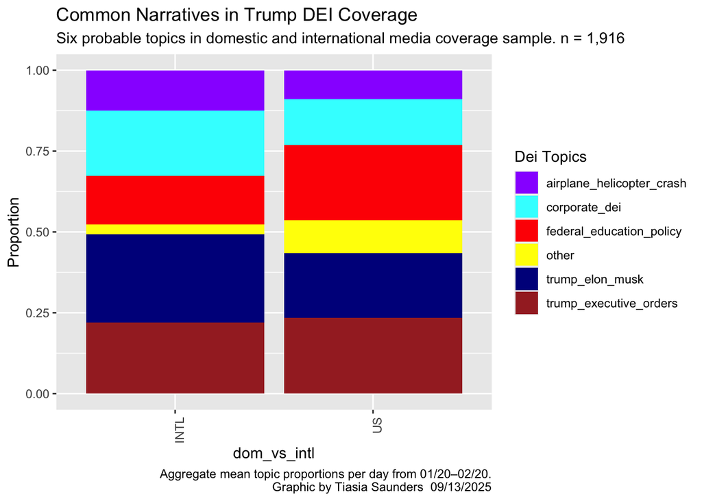

```r
ggplot(vizDataFrame, aes(x = dom_vs_intl, y = value, fill = category)) +
  geom_bar(stat = "identity") +
  ylab("Proportion") +
  scale_fill_manual(
    values = c("#9933FF", "#33FFFF", "red", "yellow", "darkblue", "brown" ),
    name = "Dei Topics"
  ) +
  theme(
    axis.text.x = element_text(angle = 90, hjust = 1)
  ) +
  labs(
    title = "Common Narratives in Trump DEI Coverage",
    subtitle = "Six probable topics in domestic and international media coverage sample. n = 1,916",
    caption = "Aggregate mean topic proportions per day from 01/20–02/20.\nGraphic by Tiasia Saunders  09/13/2025"
  )
```

## My Findings:

### Comparing International vs. Domestic Newspaper Coverage of DEI Issues under Trump: A Content Analysis

In this project, I conducted a content analysis of 1,916 news articles that mentioned DEI-related (Diversity, Equity, and Inclusion) issues during the post-affirmative action landscape, with a special focus on former President Donald Trump’s policies. My goal was to explore how coverage of these issues varied between **domestic** (U.S.-based) and **international** media outlets. Through a combination of topic modeling, bigram analysis, and sentiment analysis, I aimed to uncover the thematic, emotional, and topical patterns shaping news discourse on DEI during this period.

#### More International Coverage Than Domestic

One of the most surprising findings was that **international outlets published more articles** related to DEI and Trump than domestic newspapers. This is noteworthy given that Trump’s actions—such as the executive orders targeting federal diversity trainings and the broader dismantling of DEI programs—have **direct implications for American institutions and citizens.** Yet, international publications devoted more attention to these issues than U.S.-based media did. This raises important questions: Are domestic outlets deprioritizing DEI coverage due to political fatigue, commercial pressures, or editorial bias? Or are international outlets more attuned to global trends in democratic backsliding and human rights, recognizing Trump’s DEI rollback as part of a broader ideological shift?

This gap may suggest that American media has normalized attacks on DEI in a way that international observers have not. Alternatively, it could reflect an international interest in the U.S. as a bellwether for racial and social justice policy—particularly in the wake of the 2020 George Floyd protests and their global ripple effects.